# Autoregressive moving average

## Install packages

```python
import sys
!{sys.executable} -m pip install -r requirements.txt
```

[output not shown]

```python
import pandas as pd
import numpy as np
import os
from statsmodels.tsa.arima_model import ARMA
import matplotlib.pyplot as plt
import seaborn as sns
import quiz_tests
```

```python
sns.set()
#note that for the figure size to show, this cell should be run
#separately from the import of pyplot
plt.style.use('ggplot')
plt.rcParams['figure.figsize'] = (14, 8)
```

## Simulate return series with autoregressive properties

```python
from statsmodels.tsa.arima_process import ArmaProcess
np.random.seed(200)

ar_params = np.array([1, -0.5])
ma_params = np.array([1, -0.3])
ret = ArmaProcess(ar_params, ma_params).generate_sample(nsample=5*252)

ret = pd.Series(ret)
drift = 100
price = pd.Series(np.cumsum(ret)) + drift
```

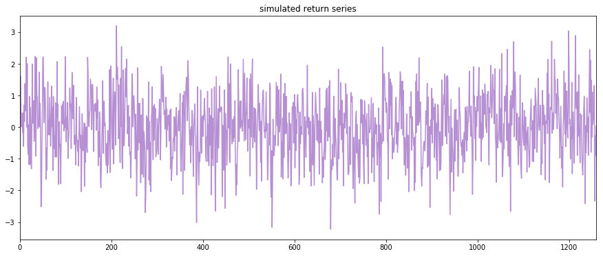

```python
ret.plot(figsize=(15,6), color=sns.xkcd_rgb["pale purple"], title="simulated return series")
plt.show()
```

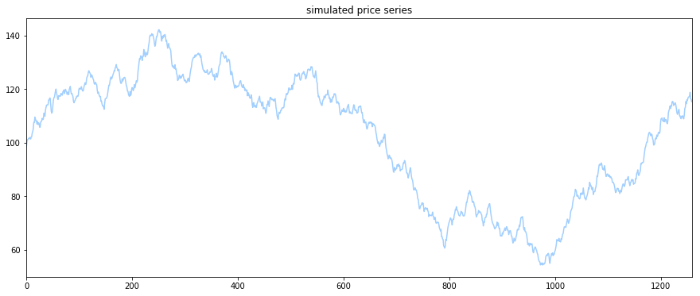

```python
price.plot(figsize=(15,6), color=sns.xkcd_rgb["baby blue"], title="simulated price series")
plt.show()
```

### log returns

```python
lret = np.log(price) - np.log(price.shift(1))
print(price.shape)
print(lret.shape)
lret = lret[1:]
print(lret.shape)
```

```
(1260,)
(1260,)
(1259,)
```

## autocorrelation

Use autocorrelation to get a sense of what lag to use for the autoregressive model.

```python
from statsmodels.graphics.tsaplots import plot_acf
```

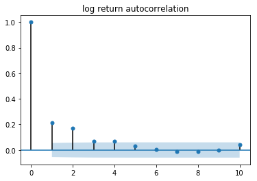

```python
_ = plot_acf(lret,lags=10, title='log return autocorrelation')
```

Since the sample series was simulated to have autoregressive properties, we also see autocorrelation between the current periods and the lags.

Note that with actual stock data, there won't be much autocorrelation of returns from one day to the next.  
Stock returns (log returns and normal returns) can be described as a "random walk", in that each new period's value is more or less random.

## plot partial autocorrelation

```python
from statsmodels.graphics.tsaplots import plot_pacf
```

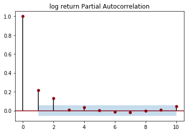

```python
_ = plot_pacf(lret, lags=10, title='log return Partial Autocorrelation', color=sns.xkcd_rgb["crimson"])
```

## Ljung-Box Test

The Ljung-Box test helps us check whether the lag we chose gives autocorrelations that are significantly different from zero. The null hypothesis is that the previous lags as a whole are not correlated with the current period. If the p-value is small enough (say 0.05), we can reject the null and assume that the past lags have some correlation with the current period.

```
returns:
lbvalue (float or array) – test statistic
pvalue (float or array) – p-value based on chi-square distribution
... (we'll ignore the other outputs, which are for another similar hypothesis test)
```

```python
from statsmodels.stats.diagnostic import acorr_ljungbox
```

```python
lb_test_stat, lb_p_value = acorr_ljungbox(lret,lags=20)
lb_p_value
```

```
array([  2.01640711e-14,   1.24123312e-21,   5.10501473e-22,
         1.86446247e-22,   6.13688232e-22,   2.96811370e-21,
         1.18392407e-20,   4.64232373e-20,   1.78935377e-19,
         2.36770725e-19,   5.54712773e-19,   1.32980392e-18,
         3.72359442e-18,   5.86709112e-18,   1.72205886e-17,
         4.22143078e-17,   1.15704571e-16,   9.89290170e-17,
         2.59299780e-16,   1.50593115e-16])
```

## Discussion

Since this series was simulated to have autoregressive properties, the Ljung-Box test shows p-values less than 0.05 for the 20 lag periods that we tested.

## Fit an ARMA model

For the purpose of familiarizing ourselves with the ARMA model, we'll fit the model to our simulated return series.

We'll just use one lag for the autoregression and one lag for the moving average.  
Check out the [statsmodel arma](https://www.statsmodels.org/dev/generated/statsmodels.tsa.arima_model.ARMA.html) documentation.

```python
from statsmodels.tsa.arima_model import ARMA
```

```python
AR_lag_p = 1
MA_lag_q = 1
order = (AR_lag_p, MA_lag_q)
arma_model = ARMA(lret.values, order=order)
arma_result = arma_model.fit()

print(len(lret))
print(len(arma_result.fittedvalues))
###
print(arma_result.fittedvalues)
print(arma_result.arparams)
print(arma_result.maparams)



arma_pred = pd.Series(arma_result.fittedvalues)
```

```
1259
1259
[ 0.00013142  0.00374523  0.00361166 ..., -0.00262876 -0.001603   -0.00219096]
[ 0.64673473]
[-0.45122057]
```

## View fitted predictions against actual values

```
Fitted AR parameter 0.65, MA parameter -0.45
```

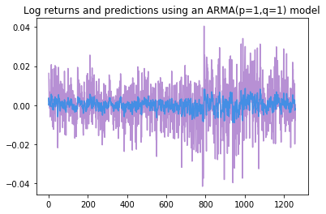

```python
plt.plot(lret, color=sns.xkcd_rgb["pale purple"])
plt.plot(arma_pred, color=sns.xkcd_rgb["dark sky blue"])
plt.title('Log returns and predictions using an ARMA(p=1,q=1) model');
print(f"Fitted AR parameter {arma_result.arparams[0]:.2f}, MA parameter {arma_result.maparams[0]:.2f}")
```

## Discussion

In general, autoregressive moving average models are not able to forecast stock returns because stock returns are non-stationary and also quite noisy.

There are other techniques that build upon the concepts of ARMA models, so the goal here was really to help you get familiar with these concepts, as they are the basis for other models that you'll see later in this module.

## Quiz: ARIMA

Fit an autoregressive integrated moving average model. Choose an order of integration of 1, autoregresion lag of 1, and moving average lag of 1.

Check out the [stats model arima](http://www.statsmodels.org/0.6.1/generated/statsmodels.tsa.arima_model.ARMAResults.html) documentation to help you.

```python
from statsmodels.tsa.arima_model import ARIMA
```

```python
def fit_arima(lret):

#     print(len(lret)) #1259


    #TODO: choose autoregression lag of 1
    AR_lag_p = 1

    #TODO: choose moving average lag of 1
    MA_lag_q = 1

    #TODO: choose order of integration 1
    order_of_integration_d = 1

    #TODO: Create a tuple of p,d,q
    order = (AR_lag_p, order_of_integration_d, MA_lag_q   )
#     order = (1,1)
    #TODO: create an ARIMA model object, passing in the values of the lret pandas series,
    # and the tuple containing the (p,d,q) order arguments

#     class statsmodels.tsa.arima_model.ARMAResults(model, params, normalized_cov_params=None, scale=1.0)[source]
    arima_model = ARIMA(lret.values, order=order)




    arima_result = arima_model.fit()
#     arima_result = arima_model.fit().ARMAResults(lret.values,order)
#     print(len(arma_result.fittedvalues))#1259

    #TODO: from the result of calling ARIMA.fit(),
#     result = arima_result.ARMAResults(arima_result, order, normalized_cov_params=None, scale=1.0)



    # save and return the fitted values, autoregression parameters, and moving average parameters
    fittedvalues = arima_result.fittedvalues #fittedvalues[1:] #Got (1259,), expected (1258,)
#     fittedvalues = pd.Series(arma_result.fittedvalues)
#   Got <class 'pandas.core.series.Series'>, expected <class 'numpy.ndarray'>

#     AssertionError: Wrong type for output fittedvalues. Got <class 'pandas.core.series.Series'>, expected <class 'numpy.ndarray'>
    arparams =     arima_result.arparams #[0]
    maparams =     arima_result.maparams #[0]

    return fittedvalues,arparams,maparams

quiz_tests.test_fit_arima(fit_arima)

# AssertionError: Wrong value for fit_arima.
```

```
Tests Passed
```

[output not shown]

```python
fittedvalues,arparams,maparams = fit_arima(lret)
arima_pred = pd.Series(fittedvalues)
plt.plot(lret, color=sns.xkcd_rgb["pale purple"])
plt.plot(arima_pred, color=sns.xkcd_rgb["jade green"])
plt.title('Log Returns and predictions using an ARIMA(p=1,d=1,q=1) model');
print(f"fitted AR parameter {arparams[0]:.2f}, MA parameter {maparams[0]:.2f}")
```

[output not shown]